# “Trabajo Final – Módulos 3 y 4 - DCSCyHD”

Agustín Romero

# Trabajo Final – Módulos 3 y 4 - DCSCyHD - Agustín Romero

# 1. Exploración y descripción de los datos

## 1.1 Descripción general del dataset y universo de análisis

El análisis se basa en el conjunto de datos del *Atlas de Gobiernos Locales y Regionales de América Latina y el Caribe* filtrado para Argentina. El dataset contiene 2.344 observaciones, correspondientes a unidades subnacionales, mayormente municipios, e incluye indicadores socioeconómicos, demográficos y de acceso a servicios básicos. Cada observación representa una unidad territorial y la mayoría de las variables se expresan como proporciones de población, con valores comprendidos entre 0 y 1. Asimismo, se incluyen variables de conteo como población total y cantidad de hogares que permiten dimensionar el tamaño relativo de los municipios. El año de referencia de los indicadores es 2022, lo que garantiza la comparabilidad temporal entre municipios. La base cuenta con 158 filas con algún NA, 5 filas tienen toda la informacion en la celda de código único, lo arreglo manualmente para recuperarlas, luego excluyo las 24 filas que refieren a provincias y de las sobrantes excluyo filas sin población. Como resultado las filas con NA que dejo fuera de la base para trabajar, corresponden a 130 unidades subprovinciales que incluyen a 89.523 personas, una porción muy poco significativa. Estos valores faltantes no se distribuyen de manera aislada por variable, lo que sugiere que no se trata de datos faltantes completamente aleatorios. Por este motivo, se opta por definir un universo analítico restringido a aquellos municipios con información completa en las variables seleccionadas. Por otra parte se transforman las variables continuas almacenadas como tipo “character” a “numeric” para no tener inconvenientes en el posterior tratamiento de las mismas.

```
 codigo_unico          region              pais           codigo_pais
 Length:2344        Length:2344        Length:2344        Length:2344
 Class :character   Class :character   Class :character   Class :character
 Mode  :character   Mode  :character   Mode  :character   Mode  :character




 nombre_subnacional nombre_nivel       nivel_gobierno      codigo_nivel
 Length:2344        Length:2344        Length:2344        Min.   :1.00
 Class :character   Class :character   Class :character   1st Qu.:2.00
 Mode  :character   Mode  :character   Mode  :character   Median :2.00
                                                          Mean   :1.99
                                                          3rd Qu.:2.00
                                                          Max.   :2.00
                                                          NA's   :5
 gob_regional        gob_local           poblacion         poblacion_anio
 Length:2344        Length:2344        Min.   :5.000e+00   Min.   :2022
 Class :character   Class :character   1st Qu.:6.235e+02   1st Qu.:2022
 Mode  :character   Mode  :character   Median :2.396e+03   Median :2022
                                       Mean   :3.956e+04   Mean   :2022
                                       3rd Qu.:9.452e+03   3rd Qu.:2022
                                       Max.   :1.752e+07   Max.   :2022
                                       NA's   :49          NA's   :5
     urbano       analfabetismo     fin_secundaria_adultos participacion_mujeres
 Min.   :0.0000   Min.   :0.00000   Min.   :0.0000         Min.   :0.0000
 1st Qu.:0.0000   1st Qu.:0.01660   1st Qu.:0.1992         1st Qu.:0.3902
 Median :0.0000   Median :0.02967   Median :0.3096         Median :0.5017
 Mean   :0.1054   Mean   :0.04130   Mean   :0.3137         Mean   :0.4865
 3rd Qu.:0.0000   3rd Qu.:0.05459   3rd Qu.:0.4186         3rd Qu.:0.5893
 Max.   :1.0000   Max.   :0.52174   Max.   :0.9083         Max.   :1.0000
 NA's   :28       NA's   :108       NA's   :108            NA's   :109
 participacion_hombres agua_mejorada    saneamiento_mejorado  electricidad
 Min.   :0.3571        Min.   :0.0000   Min.   :0.0000       Min.   :0.0500
 1st Qu.:0.7559        1st Qu.:0.5812   1st Qu.:0.4286       1st Qu.:0.9431
 Median :0.8235        Median :0.8483   Median :0.6186       Median :0.9849
 Mean   :0.8026        Mean   :0.7195   Mean   :0.5959       Mean   :0.9536
 3rd Qu.:0.8649        3rd Qu.:0.9517   3rd Qu.:0.7874       3rd Qu.:0.9965
 Max.   :1.0000        Max.   :1.0000   Max.   :1.0000       Max.   :1.0000
 NA's   :108           NA's   :108      NA's   :108          NA's   :108
```

[output cut: 11 more lines]

```
 Median :0.3008           Median :0.001538   Median :0.011280   Median :0.2919
 Mean   :0.3485           Mean   :0.003304   Mean   :0.037456   Mean   :0.2923
 3rd Qu.:0.4258           3rd Qu.:0.003376   3rd Qu.:0.024008   3rd Qu.:0.4130
 Max.   :1.0000           Max.   :0.181759   Max.   :0.754902   Max.   :0.8705
 NA's   :109              NA's   :108        NA's   :108        NA's   :108
  tics_celular      tiene_ods        hogares
 Min.   :0.0000   Min.   :0.000   Min.   :      3.0
 1st Qu.:0.8118   1st Qu.:1.000   1st Qu.:    176.8
 Median :0.8550   Median :1.000   Median :    614.5
 Mean   :0.8186   Mean   :0.956   Mean   :  10823.6
 3rd Qu.:0.8877   3rd Qu.:1.000   3rd Qu.:   2413.2
 Max.   :1.0000   Max.   :1.000   Max.   :4796105.0
 NA's   :108      NA's   :5       NA's   :108
[1] 158
[1] 0.06740614
```

| codigo_unico | region | pais | codigo_pais | nombre_subnacional | nombre_nivel | nivel_gobierno | codigo_nivel | gob_regional | gob_local | poblacion | poblacion_anio | urbano | analfabetismo | fin_secundaria_adultos | participacion_mujeres | participacion_hombres | agua_mejorada | saneamiento_mejorado | electricidad | desempleo_adulto | desempleo_adulto_mujer | desempleo_adulto_hombre | recoleccion_residuos | empleo_publico_categoria | etnia_indigena | etnia_afro | tics_computadora | tics_celular | tiene_ods | … |
| --- | --- | --- | --- | --- | --- | --- | --- | --- | --- | --- | --- | --- | --- | --- | --- | --- | --- | --- | --- | --- | --- | --- | --- | --- | --- | --- | --- | --- | --- | --- |
| ARG064660466 | América del Sur | Argentina | ARG | Lezama | Municipio | Local | 2 | Buenos Aires | Lezama | 6170 | 2022 | 0.00000000 | NA | NA | NA | NA | NA | NA | NA | NA | NA | NA | NA | NA | NA | NA | NA | NA | 0 | … |
| ARG10 | América del Sur | Argentina | ARG | Catamarca | Provincia | Regional | 1 | Catamarca | NA | 429562 | 2022 | NA | 0.022586930 | 0.49086001 | 0.5530276 | 0.7777896 | 0.94574144 | 0.77456539 | 0.9769980 | 0.071087347 | 0.09987802 | 0.050387244 | 0.8273932 | 0.50383707 | 0.002530227 | 0.018846108 | 0.35880894 | 0.8428732 | 1 | … |
| ARG14 | América del Sur | Argentina | ARG | Córdoba | Provincia | Regional | 1 | Córdoba | NA | 3840905 | 2022 | NA | 0.014909252 | 0.53895136 | 0.6132676 | 0.8391417 | 0.92752714 | 0.86689986 | 0.9935940 | 0.060018787 | 0.08626332 | 0.039956761 | 0.9368400 | 0.23945287 | 0.002851872 | 0.015466642 | 0.49790388 | 0.8734531 | 1 | … |
| ARG140562308 | América del Sur | Argentina | ARG | Assunta | Comuna | Local | 2 | Córdoba | Assunta | 55 | 2022 | 0.00000000 | 0.000000000 | 0.15151515 | 0.0000000 | 0.7619048 | 0.00000000 | 0.04000000 | 1.0000000 | 0.000000000 | NA | 0.000000000 | 0.0000000 | 0.12500000 | 0.000000000 | 0.000000000 | 0.16000000 | 0.9200000 | 1 | … |
| ARG18 | América del Sur | Argentina | ARG | Corrientes | Provincia | Regional | 1 | Corrientes | NA | 1212696 | 2022 | NA | 0.046999191 | 0.41103380 | 0.4620918 | 0.7415279 | 0.87541582 | 0.71444839 | 0.9581807 | 0.056819935 | 0.07884880 | 0.042285796 | 0.7961104 | 0.34010563 | 0.002486246 | 0.005169013 | 0.31712234 | 0.8554340 | 1 | … |
| ARG180070010 | América del Sur | Argentina | ARG | Tres de Abril | Municipio | Local | 2 | Corrientes | Tres de Abril | 3048 | 2022 | 0.00000000 | NA | NA | NA | NA | NA | NA | NA | NA | NA | NA | NA | NA | NA | NA | NA | NA | 0 | … |
| ARG180081 | América del Sur | Argentina | ARG | Manuel Derqui | Municipio | Local | 2 | Corrientes | Manuel Derqui | 1371 | 2022 | 0.00000000 | NA | NA | NA | NA | NA | NA | NA | NA | NA | NA | NA | NA | NA | NA | NA | NA | 0 | … |
| ARG180350059 | América del Sur | Argentina | ARG | Cazadores Correntinos | Municipio | Local | 2 | Corrientes | Cazadores Correntinos | 1270 | 2022 | 0.00000000 | NA | NA | NA | NA | NA | NA | NA | NA | NA | NA | NA | NA | NA | NA | NA | NA | 0 | … |
| ARG180420073 | América del Sur | Argentina | ARG | El Sombrero | Municipio | Local | 2 | Corrientes | El Sombrero | 1694 | 2022 | 0.00000000 | NA | NA | NA | NA | NA | NA | NA | NA | NA | NA | NA | NA | NA | NA | NA | NA | 0 | … |
| ARG180700143 | América del Sur | Argentina | ARG | San Isidro | Municipio | Local | 2 | Corrientes | San Isidro | 5366 | 2022 | 0.00000000 | NA | NA | NA | NA | NA | NA | NA | NA | NA | NA | NA | NA | NA | NA | NA | NA | 0 | … |

[output cut: 148 more lines]

```
[1] 154
Número de filas de provincias (Regional): 24
```

| codigo_unico | region | pais | codigo_pais | nombre_subnacional | nombre_nivel | nivel_gobierno | codigo_nivel | gob_regional | gob_local | poblacion | poblacion_anio | urbano | analfabetismo | fin_secundaria_adultos | participacion_mujeres | participacion_hombres | agua_mejorada | saneamiento_mejorado | electricidad | desempleo_adulto | desempleo_adulto_mujer | desempleo_adulto_hombre | recoleccion_residuos | empleo_publico_categoria | etnia_indigena | etnia_afro | tics_computadora | tics_celular | tiene_ods | … |
| --- | --- | --- | --- | --- | --- | --- | --- | --- | --- | --- | --- | --- | --- | --- | --- | --- | --- | --- | --- | --- | --- | --- | --- | --- | --- | --- | --- | --- | --- | --- |
| ARG10 | América del Sur | Argentina | ARG | Catamarca | Provincia | Regional | 1 | Catamarca | NA | 429562 | 2022 | NA | 2.2586929706923251E-2 | 0.4908600072321907 | 0.55302764831622109 | 0.77778958931292297 | 0.94574144328177756 | 0.77456538958602583 | 0.97699795722683125 | 7.1087346863053E-2 | 9.9878023666576901E-2 | 0.05038724 | 0.82739323454011127 | 0.50383706661294159 | 2.53022668654572E-3 | 1.884610780398089E-2 | 0.35880893817484472 | 0.84287322299578937 | 1 | … |
| ARG14 | América del Sur | Argentina | ARG | Córdoba | Provincia | Regional | 1 | Córdoba | NA | 3840905 | 2022 | NA | 1.4909252199765039E-2 | 0.5389513639956407 | 0.61326759058857683 | 0.83914168670805689 | 0.92752713725558555 | 0.86689985967746153 | 0.99359397106973402 | 6.0018787095145659E-2 | 8.6263323597466149E-2 | 0.03995676 | 0.93684000565467362 | 0.23945286534723359 | 2.8518720135486601E-3 | 1.5466642472630489E-2 | 0.49790387760853211 | 0.87345308685374401 | 1 | … |
| ARG18 | América del Sur | Argentina | ARG | Corrientes | Provincia | Regional | 1 | Corrientes | NA | 1212696 | 2022 | NA | 4.6999191341218348E-2 | 0.41103379603835988 | 0.46209184058810199 | 0.74152792262097134 | 0.87541582195539924 | 0.71444838954163448 | 0.95818072527562803 | 5.6819935299611518E-2 | 7.8848799357114641E-2 | 0.04228580 | 0.79611041639448288 | 0.34010563182739861 | 2.4862460305222702E-3 | 5.1690133322045903E-3 | 0.31712234405976641 | 0.85543396691345308 | 1 | … |
| ARG2 | América del Sur | Argentina | ARG | Ciudad Autónoma de Buenos Aires | Provincia | Regional | 1 | Ciudad Autónoma de Buenos Aires | NA | 3121707 | 2022 | NA | 5.0608475184162199E-3 | 0.78066033600774676 | 0.74673895401083912 | 0.8759328451596613 | 0.99757858956095358 | 0.98668961699897795 | 0.99950287775651236 | 5.0960618687073397E-2 | 6.2326212634888148E-2 | 0.04007056 | 0.97853615725235077 | 0.23118872495045151 | 5.4498738826444801E-3 | 2.139155013718028E-2 | 0.68425536640425322 | 0.87370145249923215 | 1 | … |
| ARG22 | América del Sur | Argentina | ARG | Chaco | Provincia | Regional | 1 | Chaco | NA | 1129606 | 2022 | NA | 6.1530863391279139E-2 | 0.36159965881688411 | 0.46723329320227852 | 0.75484938207233876 | 0.8065474436614104 | 0.59431015775845042 | 0.93929540798463662 | 5.4469990907474147E-2 | 7.3231546291310928E-2 | 0.04243536 | 0.76191202415159209 | 0.37862722890727968 | 2.5953794854155499E-3 | 3.9138208932312617E-2 | 0.2895427396794914 | 0.84211675719896417 | 1 | … |
| ARG26 | América del Sur | Argentina | ARG | Chubut | Provincia | Regional | 1 | Chubut | NA | 592621 | 2022 | NA | 2.1860086883947871E-2 | 0.47519202565313579 | 0.61612621578552107 | 0.84973746493955304 | 0.9684339896584222 | 0.88941389235589297 | 0.99051172979444202 | 6.166111741550382E-2 | 8.3756973967159185E-2 | 0.04569604 | 0.92340330788804081 | 0.33850507685759917 | 7.5413300235273699E-3 | 8.4995109918812872E-2 | 0.57282406581930256 | 0.91495580631192841 | 1 | … |

| codigo_unico | region | pais | codigo_pais | nombre_subnacional | nombre_nivel | nivel_gobierno | codigo_nivel | gob_regional | gob_local | poblacion | poblacion_anio | urbano | analfabetismo | fin_secundaria_adultos | participacion_mujeres | participacion_hombres | agua_mejorada | saneamiento_mejorado | electricidad | desempleo_adulto | desempleo_adulto_mujer | desempleo_adulto_hombre | recoleccion_residuos | empleo_publico_categoria | etnia_indigena | etnia_afro | tics_computadora | tics_celular | tiene_ods | … |
| --- | --- | --- | --- | --- | --- | --- | --- | --- | --- | --- | --- | --- | --- | --- | --- | --- | --- | --- | --- | --- | --- | --- | --- | --- | --- | --- | --- | --- | --- | --- |
| ARG064660466 | América del Sur | Argentina | ARG | Lezama | Municipio | Local | 2 | Buenos Aires | Lezama | 6170 | 2022 | 0.00000000 | NA | NA | NA | NA | NA | NA | NA | NA | NA | NA | NA | NA | NA | NA | NA | NA | 0 | … |
| ARG140562308 | América del Sur | Argentina | ARG | Assunta | Comuna | Local | 2 | Córdoba | Assunta | 55 | 2022 | 0.00000000 | 0 | 0.15151515151515149 | 0 | 0.76190476190476186 | 0 | 0.04 | 1 | 0 | NA | 0.000000000 | 0 | 0.125 | 0 | 0 | 0.16 | 0.92 | 1 | … |
| ARG180070010 | América del Sur | Argentina | ARG | Tres de Abril | Municipio | Local | 2 | Corrientes | Tres de Abril | 3048 | 2022 | 0.00000000 | NA | NA | NA | NA | NA | NA | NA | NA | NA | NA | NA | NA | NA | NA | NA | NA | 0 | … |
| ARG180081 | América del Sur | Argentina | ARG | Manuel Derqui | Municipio | Local | 2 | Corrientes | Manuel Derqui | 1371 | 2022 | 0.00000000 | NA | NA | NA | NA | NA | NA | NA | NA | NA | NA | NA | NA | NA | NA | NA | NA | 0 | … |
| ARG180350059 | América del Sur | Argentina | ARG | Cazadores Correntinos | Municipio | Local | 2 | Corrientes | Cazadores Correntinos | 1270 | 2022 | 0.00000000 | NA | NA | NA | NA | NA | NA | NA | NA | NA | NA | NA | NA | NA | NA | NA | NA | 0 | … |
| ARG180420073 | América del Sur | Argentina | ARG | El Sombrero | Municipio | Local | 2 | Corrientes | El Sombrero | 1694 | 2022 | 0.00000000 | NA | NA | NA | NA | NA | NA | NA | NA | NA | NA | NA | NA | NA | NA | NA | NA | 0 | … |
| ARG180700143 | América del Sur | Argentina | ARG | San Isidro | Municipio | Local | 2 | Corrientes | San Isidro | 5366 | 2022 | 0.00000000 | NA | NA | NA | NA | NA | NA | NA | NA | NA | NA | NA | NA | NA | NA | NA | NA | 0 | … |
| ARG180910188 | América del Sur | Argentina | ARG | Cecilio Echavarría | Municipio | Local | 2 | Corrientes | Cecilio Echavarría | 1305 | 2022 | 0.00000000 | NA | NA | NA | NA | NA | NA | NA | NA | NA | NA | NA | NA | NA | NA | NA | NA | 0 | … |
| ARG181260318 | América del Sur | Argentina | ARG | Pago de los Deseos | Municipio | Local | 2 | Corrientes | Pago de los Deseos | 2259 | 2022 | 0.00000000 | NA | NA | NA | NA | NA | NA | NA | NA | NA | NA | NA | NA | NA | NA | NA | NA | 0 | … |
| ARG220630165 | América del Sur | Argentina | ARG | El Espinillo | Municipio | Local | 2 | Chaco | El Espinillo | 1526 | 2022 | 0.00000000 | NA | NA | NA | NA | NA | NA | NA | NA | NA | NA | NA | NA | NA | NA | NA | NA | 0 | … |

[output cut: 120 more lines]

| n_na_poblacion | n_valor_poblacion | total_poblacion |
| --- | --- | --- |
| 44 | 86 | 89523 |

```
 codigo_unico          region              pais           codigo_pais
 Length:2190        Length:2190        Length:2190        Length:2190
 Class :character   Class :character   Class :character   Class :character
 Mode  :character   Mode  :character   Mode  :character   Mode  :character



 nombre_subnacional nombre_nivel       nivel_gobierno      codigo_nivel
 Length:2190        Length:2190        Length:2190        Min.   :2
 Class :character   Class :character   Class :character   1st Qu.:2
 Mode  :character   Mode  :character   Mode  :character   Median :2
                                                          Mean   :2
                                                          3rd Qu.:2
                                                          Max.   :2
 gob_regional        gob_local           poblacion       poblacion_anio
 Length:2190        Length:2190        Min.   :      5   Min.   :2022
 Class :character   Class :character   1st Qu.:    656   1st Qu.:2022
 Mode  :character   Mode  :character   Median :   2522   Median :2022
                                       Mean   :  20634   Mean   :2022
                                       3rd Qu.:   9550   3rd Qu.:2022
                                       Max.   :1837168   Max.   :2022
     urbano       analfabetismo      fin_secundaria_adultos participacion_mujeres
 Min.   :0.0000   Length:2190        Length:2190            Length:2190
 1st Qu.:0.0000   Class :character   Class :character       Class :character
 Median :0.0000   Mode  :character   Mode  :character       Mode  :character
 Mean   :0.1109
 3rd Qu.:0.0000
 Max.   :1.0000
 participacion_hombres agua_mejorada      saneamiento_mejorado electricidad
 Length:2190           Length:2190        Length:2190          Length:2190
 Class :character      Class :character   Class :character     Class :character
 Mode  :character      Mode  :character   Mode  :character     Mode  :character



 desempleo_adulto   desempleo_adulto_mujer desempleo_adulto_hombre recoleccion_residuos
 Length:2190        Length:2190            Min.   :0.00000         Length:2190
 Class :character   Class :character       1st Qu.:0.01667         Class :character
 Mode  :character   Mode  :character       Median :0.02976         Mode  :character
                                           Mean   :0.03430
```

[output cut: 65 more lines]

```
 Max.   :0.30270   Max.   :0.50000        Max.   :0.31818         Max.   :1.0000
 empleo_publico_categoria etnia_indigena       etnia_afro       tics_computadora
 Min.   :0.0000           Min.   :0.000000   Min.   :0.000000   Min.   :0.0000
 1st Qu.:0.2245           1st Qu.:0.000000   1st Qu.:0.004478   1st Qu.:0.1612
 Median :0.3002           Median :0.001535   Median :0.011260   Median :0.2934
 Mean   :0.3486           Mean   :0.003263   Mean   :0.037203   Mean   :0.2935
 3rd Qu.:0.4258           3rd Qu.:0.003381   3rd Qu.:0.023973   3rd Qu.:0.4132
 Max.   :1.0000           Max.   :0.181759   Max.   :0.754902   Max.   :0.8705
  tics_celular      tiene_ods    hogares
 Min.   :0.0000   Min.   :1   Min.   :     3.0
 1st Qu.:0.8125   1st Qu.:1   1st Qu.:   180.2
 Median :0.8554   Median :1   Median :   615.0
 Mean   :0.8191   Mean   :1   Mean   :  5511.3
 3rd Qu.:0.8879   3rd Qu.:1   3rd Qu.:  2346.5
 Max.   :1.0000   Max.   :1   Max.   :485284.0
```

## 1.2 Tamaño poblacional y heterogeneidad territorial

Los municipios argentinos presentan una marcada heterogeneidad en términos de tamaño poblacional. La población mínima registrada es de apenas 5 habitantes, mientras que el máximo supera los 1.837.168, reflejando la coexistencia de pequeñas localidades rurales y grandes aglomerados urbanos dentro del mismo dataset. La distribución de la población es fuertemente asimétrica: mientras que la mediana poblacional es de aproximadamente 2.522 habitantes, el promedio supera los 20.634, lo que indica la presencia de municipios muy grandes que elevan la media. Una dinámica similar se observa en la variable hogares. Esta heterogeneidad refuerza la pertinencia de utilizar indicadores normalizados (proporciones) para el análisis comparativo, aunque también sugiere la necesidad de considerar cuidadosamente el rol del tamaño poblacional en la interpretación de los resultados.

## 1.3 Distribución de los indicadores socioeconómicos y de servicios

El análisis descriptivo de los indicadores muestra patrones diferenciados entre dimensiones:

- **Educación:**  
  La tasa de analfabetismo presenta valores bajos en la mayoría de los municipios (mediana cercana al 3%), aunque con casos extremos que superan el 50%. La finalización del secundario en adultos muestra una distribución más dispersa, con valores que oscilan entre 0 y 0,9, lo que sugiere desigualdades educativas persistentes entre territorios.
- **Mercado laboral:**  
  Las tasas de participación laboral femenina y masculina muestran niveles promedio elevados, aunque con diferencias sistemáticas por sexo, con mediana de 82% en hombres y del 50% en mujeres. El desempleo adulto presenta una mediana cercana al 4,4%, pero con valores máximos superiores al 30%, indicando una importante heterogeneidad en las condiciones del mercado de trabajo entre localidades. En la distincion por sexo del desempleo adulto, los hombres se ubican en el 3,4% en promedio con máximos de 32%; mientras que las mujeres se ubican en promedio en el 7,2% con máximos del 50%. El empleo público resulta relativamente homogéneo con una mediana del 30% y un promedio de 34,8%.
- **Servicios básicos:**  
  El acceso a electricidad es casi universal en la mayoría de los municipios (mediana cercana al 98,5%), mientras que el acceso a agua mejorada y saneamiento presenta mayores disparidades territoriales, con medianas de 84,9% y 61,9% respectivamente. En particular, el saneamiento mejorado muestra una dispersión considerable, lo que lo convierte en un indicador clave para el análisis de desigualdades en infraestructura. Mientras que la recoleccion de residuos tambien resulta heterogenea con un promedio de 67% y una mediana del 83%.
- **Tecnologías de la información y la comunicación (TIC):**  
  El acceso a telefonía celular es elevado y relativamente homogéneo con un acceso promedio del 81,9%, mientras que el acceso a computadoras presenta una mayor variabilidad con un acceso promedio de 29%, lo que sugiere la existencia de brechas digitales más profundas en este último indicador.

## 1.4 Implicancias para las etapas siguientes

La exploración descriptiva confirma que:

- el dataset presenta una **alta heterogeneidad territorial**,
- las variables capturan **dimensiones conceptualmente diferenciables pero parcialmente correlacionadas**,
- y existe un conjunto reducido pero relevante de municipios con información incompleta.

En consecuencia, resulta metodológicamente apropiado avanzar hacia una etapa de **análisis de relaciones entre variables y reducción de dimensionalidad**, con el fin de sintetizar la información disponible y preparar el terreno para la identificación de grupos de municipios con perfiles similares.

# 2. Definición conceptual de las dimensiones de análisis

Previo a cualquier técnica de reducción de dimensionalidad, resulta necesario establecer un marco conceptual que permita agrupar los indicadores disponibles en dimensiones analíticas coherentes en linea con las propuestas ex ante por la propia consigna: demográfica, educativa, laborales, de acceso a servicios, étnica, de acceso a tecnologías de la información, y de disponibilidad de indicadores de desarrollo sostenible; descontando las variables de identificación de la unidad territorial. Esta clasificación cumple una doble función: por un lado, orienta la selección y organización de variables; por otro, proporciona un criterio interpretativo para los resultados estadísticos posteriores.

```r
dicc_atlas_clasif <- read_excel(
  "data/dicc_atlas_jurisdiccion/dicc_atlas_clasif.xlsx"
)


DT::datatable(
  dicc_atlas_clasif,
  caption = "Anexo A. Diccionario Atlas Argentina- con clasificación",
  options = list(
    scrollY = "500px",
    scrollX = TRUE,
    paging = FALSE,
    dom = 't'
  ),
  rownames = FALSE
)
```

| variable | definicion | dimension |
| --- | --- | --- |
| codigo_unico | Identificador único de la unidad territorial subnacional dentro del Atlas | id |
| region | Región geográfica de América Latina y el Caribe a la que pertenece la unidad territorial | id |
| pais | Nombre del país al que pertenece la unidad subnacional | id |
| codigo_pais | Código identificador del país | id |
| nombre_subnacional | Nombre oficial de la unidad subnacional (provincia, estado, municipio, etc.) | id |
| nombre_nivel | Denominación del nivel administrativo (por ejemplo: provincia, municipio, departamento) | id |
| nivel_gobierno | Nivel de gobierno de la unidad territorial (local o regional) | id |
| codigo_nivel | Código del nivel de gobierno según la clasificación del Atlas | id |
| gob_regional | Indicador de pertenencia al nivel de gobierno regional | id |
| gob_local | Indicador de pertenencia al nivel de gobierno local | id |

[output cut: 21 more lines]

## 2.1 Dimensión demográfica

La dimensión demográfica incluye variables que describen la estructura básica de la población y el grado de urbanización de las unidades territoriales. Estas variables no reflejan directamente niveles de bienestar, pero condicionan de manera estructural las dinámicas sociales, económicas y de provisión de servicios. Se incluyen:

- proporción de población urbana
- cantidad de hogares y tamaño poblacional (utilizado solo con fines descriptivos). Estas se considera una variable estructural de contexto y **no se incorpora en las técnicas multivariadas**, dado su alto poder de dominancia estadística.

```r
vars_demografica <- dicc_atlas_clasif %>%
  filter(dimension == "demografica") %>%
  pull(variable)
```

## 2.2 Dimensión educativa

La dimensión educativa es un proxy del stock de capital humano acumulado en cada municipio. El analfabetismo y la finalización del nivel secundario en adultos reflejan trayectorias educativas históricas y están estrechamente asociados con oportunidades laborales, ingresos y condiciones de vida. Se incluyen:

- tasa de analfabetismo
- proporción de adultos con secundario completo

```r
vars_educacion <- dicc_atlas_clasif %>%
  filter(dimension == "educacion") %>%
  pull(variable)
```

## 2.3 Dimensión del mercado laboral

Esta dimensión describe el grado de integración de la población al mercado de trabajo y las condiciones generales de empleo a nivel local. Se incluyen indicadores de participación laboral, desempleo y empleo público, distinguiendo en algunos casos por sexo. La inclusión de indicadores diferenciados por sexo responde a la intención de capturar desigualdades estructurales del mercado de trabajo, aun cuando se espere una alta correlación entre ellos. Se incluyen:

- tasas de participación laboral (mujeres y hombres)
- tasas de desempleo adulto (total y por sexo)
- proporción de empleo público

```r
vars_laboral <- dicc_atlas_clasif %>%
  filter(dimension == "laboral") %>%
  pull(variable)
```

## 2.4 Dimensión de acceso a servicios básicos

Esta dimensión refleja el grado de cobertura de infraestructura básica y servicios esenciales a nivel municipal, constituyendo un componente central del bienestar material. Se incluyen:

- acceso a agua mejorada
- acceso a saneamiento mejorado
- acceso a electricidad
- recolección de residuos

```r
vars_servicios <- dicc_atlas_clasif %>%
  filter(dimension == "servicios") %>%
  pull(variable)
```

## 2.5 Dimensión étnica

La dimensión étnica describe la composición poblacional en términos de autoidentificación indígena y afrodescendiente. Estas variables no constituyen indicadores de desarrollo en sí mismos, pero se asocian a desigualdades estructurales y territoriales. Su inclusión busca permitir una caracterización más completa de los perfiles territoriales. Se incluyen:

- proporción de población indígena
- proporción de población afrodescendiente

```r
vars_etnia <- dicc_atlas_clasif %>%
  filter(dimension == "etnia") %>%
  pull(variable)
```

## 2.6 Dimensión de tecnologías de la información y la comunicación (TIC)

Esta dimensión capta el acceso a tecnologías digitales, cada vez más relevantes para la integración social, educativa y productiva de los territorios. Se incluyen:

- acceso a computadora
- acceso a teléfono celular

```r
vars_tics <- dicc_atlas_clasif %>%
  filter(dimension == "tics") %>%
  pull(variable)
```

## 2.7 Información ODS y variables de tamaño

Por el contrario, las variables de tamaño absoluto (`poblacion`, `hogares`) se excluyen de las técnicas de reducción de dimensionalidad, dado que reflejan escala y no condiciones estructurales comparables.

```r
vars_tamano <- dicc_atlas_clasif %>%
  filter(dimension == "cant_hogares") %>%
  pull(variable)

vars_excluir_pca <- c("poblacion", vars_tamano)
```

# 3. Esquema de PCA por dimensión y reducción de la dimensionalidad:

Una vez definidas las dimensiones conceptuales, se procede a la delimitación del universo analítico que será utilizado en las técnicas multivariadas. Dado que el PCA y los métodos de clustering requieren matrices completas, se opta por restringir el análisis a aquellas unidades territoriales con información disponible en todas las variables sustantivas seleccionadas, en este caso la restricción ya fue realizada previamente. La estrategia que combina una **definición conceptual ex ante** clara de dimensiones, y una **preparación estadística controlada** del universo analítico, con la preservación de la mayor cantidad posible de información sustantiva; habilita avanzar hacia una etapa de reducción de dimensionalidad mediante PCA **por dimensiones**, permitiendo interpretar los componentes principales como síntesis internas de cada ámbito analítico, antes de integrar los resultados en una tipología territorial más general.

```r
vars_pca <- c(
  vars_demografica,
  vars_educacion,
  vars_laboral,
  vars_servicios,
  vars_etnia,
  vars_tics
)

base_pca <- base_sin_na %>%
  select(all_of(c("codigo_unico", vars_pca))) %>%
  drop_na()

nrow(base_sin_na)
```

```
[1] 2190
```

```r
nrow(base_pca)
```

```
[1] 2190
```

El siguiente paso consiste en realizar análisis de componentes principales independientes para cada dimensión conceptual, en lugar de un PCA único sobre todas las variables. Esta decisión responde a tres razones centrales:

1. Evitar que dimensiones con mayor varianza (ej. mercado laboral o servicios) dominen el resultado global.
2. Preservar la interpretabilidad sustantiva de los componentes, facilitando la lectura como “ejes latentes” de cada dimensión.
3. Permitir decisiones diferenciadas sobre número de componentes retenidos según el contenido de cada grupo de variables.

En todos los casos se trabaja con la base sin NA (`base_pca`), se utilizan variables estandarizadas, y el PCA se utiliza como una herramienta exploratoria y descriptiva, no predictiva. El análisis de componentes principales se realiza sobre la base sin valores faltantes compuesta por 2.190 unidades territoriales, lo que representa aproximadamente el 93% del universo original.

## 3.1 PCA – Dimensión demográfica, urbana y de disponibilidad estadística.

Busca capturar diferencias estructurales entre municipios asociadas al grado de urbanización y tamaño, que condicionan la provisión de servicios, la dinámica del mercado laboral y la organización institucional, pero que no constituyen en sí mismas una dimensión de desempeño socioeconómico.

- **urbano**: proporción de la población que reside en áreas urbanas
- **poblacion**: tamaño poblacional absoluto
- **hogar**: cantidad de hogares.
- **tiene_ods**: indicador de disponibilidad de información ODS

Estas variables funcionan como condicionantes del perfil municipal. Se mantienen como indicador directo y eventualmente se utilizará como variable auxiliar o de control en etapas posteriores (clustering o interpretación). No se corre PCA aquí.

## 3.2 PCA – Dimensión educativa

El nivel educativo estructural de la población adulta, incluye las variables:

- `analfabetismo`
- `fin_secundaria_adultos`

```r
# 1. Convertir todas las columnas de vars_pca a numeric
base_pca <- base_pca %>%
  mutate(across(all_of(vars_pca), ~ as.numeric(.)))

# 2. Verificar que todas sean numéricas
sapply(base_pca %>% select(all_of(vars_pca)), class)
```

```
               poblacion                   urbano            analfabetismo
               "numeric"                "numeric"                "numeric"
  fin_secundaria_adultos    participacion_mujeres    participacion_hombres
               "numeric"                "numeric"                "numeric"
        desempleo_adulto   desempleo_adulto_mujer  desempleo_adulto_hombre
               "numeric"                "numeric"                "numeric"
empleo_publico_categoria            agua_mejorada     saneamiento_mejorado
               "numeric"                "numeric"                "numeric"
            electricidad     recoleccion_residuos           etnia_indigena
               "numeric"                "numeric"                "numeric"
              etnia_afro         tics_computadora             tics_celular
               "numeric"                "numeric"                "numeric"
```

```r
vars_educacion <- c(
  "analfabetismo",
  "fin_secundaria_adultos"
)

pca_educacion <- base_pca %>%
  select(all_of(vars_educacion)) %>%
  scale() %>%
  prcomp(center = TRUE, scale. = TRUE)

summary(pca_educacion)
```

```
Importance of components:
                          PC1    PC2
Standard deviation     1.2454 0.6700
Proportion of Variance 0.7755 0.2245
Cumulative Proportion  0.7755 1.0000
```

```r
pca_educacion$rotation
```

```
                              PC1        PC2
analfabetismo           0.7071068 -0.7071068
fin_secundaria_adultos -0.7071068 -0.7071068
```

Resultados e interpretación de la varianza:

El PCA arroja los siguientes resultados: **Primer componente (PC1):** explica el **77,5% de la varianza total.** **Segundo componente (PC2):** explica el **22,5% restante.** PC1 puede interpretarse como un eje de grado educativo rezagado o de piso mínimo obligatorio superado. PC2 no presenta un componente claro y sustantivo por su significativa menor explicacion de la varianza del vector educativo; su bajo peso explicativo y su menor claridad conceptual, **no justifican su retención** para etapas posteriores. La oposición casi perfecta entre analfabetismo y finalización del secundario indica que, en el nivel municipal, ambas variables capturan un mismo fenómeno latente, observado desde extremos distintos del proceso educativo. Para facilitar la interpretación, el índice puede reescalarse invirtiendo el signo, de modo que valores más altos representen mejores niveles educativos. El score del PCA funciona como una variable sintética, permite reducir dimensionalidad, evitar colinealidad y utilizar la dimensión educativa en análisis posteriores como clustering o tipologías municipales. El índice educativo, puede usarse como **variable dependiente** (ej. explicar educación por estructura productiva), o como **regresor** (ej. explicar servicios según capital educativo), y evita multicolinealidad entre variables educativas.

## 3.3 PCA – Dimensión mercado laboral

La condicion estructurales del mercado de trabajo local incluye las variables:

- `participacion_mujeres`
- `participacion_hombres`
- `desempleo_adulto`
- `desempleo_adulto_mujer`
- `desempleo_adulto_hombre`
- `empleo_publico_categoria`

```r
vars_laboral <- c(
  "participacion_mujeres",
  "participacion_hombres",
  "desempleo_adulto",
  "desempleo_adulto_mujer",
  "desempleo_adulto_hombre",
  "empleo_publico_categoria"
)

pca_laboral <- base_pca %>%
  select(all_of(vars_laboral)) %>%
  scale() %>%
  prcomp(center = TRUE, scale. = TRUE)

summary(pca_laboral)
```

```
Importance of components:
                          PC1    PC2    PC3    PC4     PC5     PC6
Standard deviation     1.6798 1.2044 1.0238 0.6458 0.50366 0.09286
Proportion of Variance 0.4703 0.2418 0.1747 0.0695 0.04228 0.00144
Cumulative Proportion  0.4703 0.7121 0.8868 0.9563 0.99856 1.00000
```

```r
pca_laboral$rotation
```

```
                                PC1        PC2          PC3        PC4         PC5
participacion_mujeres    -0.2176269  0.5975098  0.490403230 -0.2088273  0.55498448
participacion_hombres    -0.3458883  0.6035531 -0.038457668  0.1087714 -0.70890373
desempleo_adulto          0.5571332  0.2838424 -0.006637849 -0.0667466 -0.02342422
desempleo_adulto_mujer    0.4668740  0.3332359 -0.135167328  0.6870391  0.16023926
desempleo_adulto_hombre   0.5289706  0.1267829  0.047129087 -0.6301994 -0.25983007
empleo_publico_categoria  0.1575473 -0.2664942  0.858772532  0.2663285 -0.30937154
                                  PC6
participacion_mujeres    -0.059233930
participacion_hombres     0.015172082
desempleo_adulto          0.777166814
desempleo_adulto_mujer   -0.393716883
desempleo_adulto_hombre  -0.487064788
empleo_publico_categoria  0.005272605
```

Resultados e interpretación de la varianza:

El análisis identifica un primer componente (PC1) que explica el **47,1% de la varianza**, seguido por un segundo componente (PC2) con **24,1%** y un tercer componente (PC3) con **17,5%**. En conjunto, los tres primeros componentes concentran más del **88% de la variabilidad** del sistema laboral municipal. El **PC1** se interpreta como un eje de **desempeño laboral general del municipio**, dominado por cargas positivas en las tasas de desempleo adulto (total, femenino y masculino) y cargas negativas en la participación laboral. Este componente ordena a los municipios según un gradiente de fragilidad del mercado de trabajo: valores altos del score indican mayores niveles de desempleo y menor participación, mientras que valores bajos reflejan una inserción laboral relativamente más favorable. Para facilitar la lectura sustantiva, el índice puede invertirse de modo que valores más altos representen mejores condiciones laborales. El **PC2** captura principalmente un eje de **participación laboral**, con cargas elevadas y positivas tanto en participación femenina como masculina. A diferencia del PC1, este componente no refleja desempleo sino intensidad de participación en el mercado de trabajo. Su interpretación es sustantiva, pero remite a un fenómeno distinto del desempeño laboral general; por ello, su uso resulta pertinente solo si el análisis requiere distinguir entre niveles de desempleo y niveles de participación. El **PC3**, con un **17,5% de varianza explicada**, está fuertemente asociado al empleo público, diferenciando municipios según el peso relativo de este sector. Si bien no sintetiza el conjunto del sistema laboral, puede considerarse relevante cuando el foco analítico está puesto en la estructura ocupacional o en el rol del empleo público como amortiguador del desempleo. La dimensión laboral no se sintetiza adecuadamente en un solo índice; requiere al menos tres ejes para distinguir mercados frágiles, baja participación y alta dependencia del empleo público.

## 3.4 PCA – Dimensión servicios básicos

**Se busca** analizar el grado de cobertura de infraestructura y servicios esenciales a partir de las siguientes variables:

- `agua_mejorada`
- `saneamiento_mejorado`
- `electricidad`
- `recoleccion_residuos`

```r
vars_servicios <- c(
  "agua_mejorada",
  "saneamiento_mejorado",
  "electricidad",
  "recoleccion_residuos"
)

pca_servicios <- base_pca %>%
  select(all_of(vars_servicios)) %>%
  scale() %>%
  prcomp(center = TRUE, scale. = TRUE)

summary(pca_servicios)
```

```
Importance of components:
                         PC1    PC2    PC3     PC4
Standard deviation     1.571 0.8517 0.6724 0.59538
Proportion of Variance 0.617 0.1814 0.1130 0.08862
Cumulative Proportion  0.617 0.7983 0.9114 1.00000
```

```r
pca_servicios$rotation
```

```
                            PC1        PC2        PC3         PC4
agua_mejorada        -0.4493239 -0.7297954 -0.4666557 -0.21849289
saneamiento_mejorado -0.5354804  0.1836318  0.5257075 -0.63495813
electricidad         -0.4642884  0.6457570 -0.6007367  0.08092977
recoleccion_residuos -0.5438797 -0.1291354  0.3807618  0.73657274
```

Resultados e interpretación de la varianza:

El PCA muestra un primer componente (PC1) que explica el **61,7% de la varianza**, seguido por un segundo componente (PC2) con **18,2%**. Los componentes restantes aportan variabilidad adicional, pero de menor relevancia sustantiva. El **PC1** se interpreta como un eje de **acceso general a servicios básicos**, ya que todas las variables (agua mejorada, saneamiento, electricidad y recolección de residuos) presentan cargas elevadas y del mismo signo. Este componente sintetiza un fenómeno de infraestructura básica integral: los municipios se ordenan según su nivel global de cobertura de servicios esenciales. Dado el signo negativo de las cargas, valores más bajos del score indican mayor acceso, por lo que resulta conveniente invertir el índice para una lectura directa. El **PC2** introduce una diferenciación entre tipos de servicios, particularmente entre electricidad y agua/saneamiento. Este componente no representa un gradiente de acceso general, sino un **perfil diferencial de cobertura**, útil únicamente si se desea distinguir municipios con patrones específicos de provisión de servicios. Dado que interesa **tipologías de provisión de servicios**, PC2 **vale la pena.**

## 3.5 PCA – Dimensión TIC

**Busca** captar brechas digitales a nivel territorial a partir de las siguientes variables:

- `tics_computadora`
- `tics_celular`

```r
vars_tics <- c(
  "tics_computadora",
  "tics_celular"
)

pca_tics <- base_pca %>%
  select(all_of(vars_tics)) %>%
  scale() %>%
  prcomp(center = TRUE, scale. = TRUE)

summary(pca_tics)
```

```
Importance of components:
                          PC1    PC2
Standard deviation     1.1772 0.7838
Proportion of Variance 0.6929 0.3071
Cumulative Proportion  0.6929 1.0000
```

```r
pca_tics$rotation
```

```
                        PC1        PC2
tics_computadora -0.7071068 -0.7071068
tics_celular     -0.7071068  0.7071068
```

Resultados e interpretación de la varianza:

El PCA identifica un primer componente (PC1) que explica el **69,2% de la varianza**, seguido por un segundo componente (PC2) que explica el **30,8%** restante. El **PC1** se interpreta como un eje de **acceso digital general**, ya que el acceso a computadora y a celular cargan de forma idéntica y en el mismo sentido. Este componente sintetiza la inclusión digital básica de los municipios, ordenándolos según el nivel conjunto de acceso a tecnologías de la información. El signo negativo indica que valores más bajos del score corresponden a mayor acceso, por lo que resulta conveniente invertir el índice para su interpretación sustantiva. El **PC2** refleja una **oposición entre tipos de dispositivos**, diferenciando municipios donde predomina el acceso vía celular de aquellos con mayor acceso a computadoras. Aunque explica una proporción relevante de la varianza, no sintetiza el fenómeno de inclusión digital en su conjunto, sino una diferencia composicional. Su interpretación resulta pertinente solo si el análisis busca distinguir modalidades de acceso, más que niveles generales de conectividad, considerados altos; dado que no es lo mismo conectividad “básica” que capacidad digital instalada, distinguimos PC2.

## 3.6 PCA – Dimensión étnica

**Busca** describir diferencias en la composición étnica de los territorios a partir de las variables:

- `etnia_indigena`
- `etnia_afro`

```r
vars_etnia <- c(
  "etnia_indigena",
  "etnia_afro"
)

pca_etnia <- base_pca %>%
  select(all_of(vars_etnia)) %>%
  scale() %>%
  prcomp(center = TRUE, scale. = TRUE)

summary(pca_etnia)
```

```
Importance of components:
                          PC1    PC2
Standard deviation     1.0154 0.9844
Proportion of Variance 0.5155 0.4845
Cumulative Proportion  0.5155 1.0000
```

```r
pca_etnia$rotation
```

```
                      PC1        PC2
etnia_indigena -0.7071068 -0.7071068
etnia_afro     -0.7071068  0.7071068
```

Resultados e interpretación de la varianza:

El PCA presenta dos componentes con pesos prácticamente equivalentes: el PC1 explica el **51,6% de la varianza**, y el PC2 el **48,4%** restante. El **PC1** puede interpretarse como un eje de **presencia relativa de población étnicamente identificada**, dado que tanto la población indígena como afrodescendiente cargan de forma similar y en el mismo sentido. Este componente ordena a los municipios según el peso agregado de estos grupos en la estructura poblacional. El signo negativo implica que valores más bajos del score corresponden a mayor presencia relativa, por lo que el índice puede invertirse para facilitar su lectura. El **PC2** introduce una diferenciación entre **tipos de población étnica**, oponiendo municipios con mayor presencia indígena a aquellos con mayor presencia afrodescendiente. Este componente no representa un gradiente de intensidad étnica, sino una **diferencia composicional**, y solo resulta relevante si el análisis requiere distinguir perfiles étnicos específicos más que niveles agregados de presencia. **Cerca de 0** → baja o nula presencia étnica registrada. **Valores extremos PC1** → alta presencia étnica. **Signo PC2** → *qué grupo predomina*

## 3.7 Base Prefiles municipales

[output not shown]

```r
base_perfiles <- base_sin_na %>%
  select(
    codigo_unico,
    poblacion,
    urbano,
    tiene_ods
  ) %>%
  bind_cols(
    scores_educacion,
    scores_laboral,
    scores_servicios,
    scores_tics,
    scores_etnia
  )

# Chequeo rápido
head(base_perfiles)


# ======================================================
# TABLA 1 – RESUMEN GENERAL DE LA BASE FINAL
# ======================================================

resumen_base <- base_perfiles %>%
  summarise(
    n_municipios = n(),
    poblacion_total = sum(poblacion, na.rm = TRUE),
    poblacion_promedio = mean(poblacion, na.rm = TRUE),
    poblacion_mediana = median(poblacion, na.rm = TRUE),
    proporcion_urbana = mean(urbano, na.rm = TRUE)
  )

write_xlsx(
  resumen_base,
  "outputs/tablas/01_resumen_base.xlsx"
)
```

# 4. Fase de Aprendizaje No Supervisado y Caracterización Municipal

Este apartado describe los pasos metodológicos seguidos para la construcción de una tipología de municipios mediante técnicas de **aprendizaje no supervisado**, a partir del objeto final generado en la etapa de **reducción de dimensionalidad mediante Análisis de Componentes Principales (PCA)**. El objetivo es identificar patrones territoriales y desigualdades estructurales entre municipios, utilizando información comparable y estandarizada.

## 4.1 Determinación del número de clusters

Previo a la aplicación del algoritmo de *K-means*, se evaluó la cantidad adecuada de grupos a conformar. Dado que este método requiere fijar ex ante el número de clusters, se recurrió a criterios habituales del análisis de conglomerados para orientar esta decisión. En particular, se analizaron distintos valores de *k* considerando el equilibrio entre la capacidad de representación de la heterogeneidad territorial y la necesidad de mantener una tipología interpretable.

Uno de los criterios utilizados fue el **“punto de quiebre”**, que se basa en observar la evolución de la variabilidad interna de los clusters a medida que aumenta el número de grupos. A medida que *k* crece, la suma de las distancias intra-cluster disminuye, aunque a partir de cierto punto las mejoras adicionales son marginales. El valor de *k* seleccionado corresponde a aquel a partir del cual la reducción de la variabilidad interna deja de ser significativa, lo que indica un equilibrio razonable entre ajuste del modelo y parsimonia.

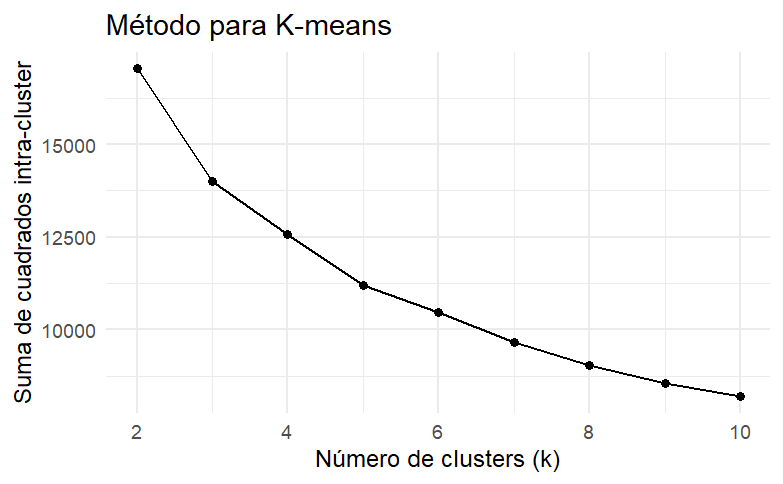

```r
vars_clustering <- c(
  "educacion_nivel",
  "laboral_desempeno", "laboral_participacion", "laboral_empleo_publico",
  "servicios_acceso_general", "servicios_composicion",
  "tics_acceso_general", "tics_tipo_acceso",
  "etnia_presencia", "etnia_composicion"
)

matriz_clustering <- base_perfiles %>%
  select(all_of(vars_clustering)) %>%
  drop_na()

#Estandarizamos

matriz_clustering_scaled <- scale(matriz_clustering)

#determinamos k

set.seed(123)

wss <- map_dbl(
  2:10,
  ~ kmeans(matriz_clustering_scaled, centers = .x, nstart = 25)$tot.withinss
)

quiebre_df <- tibble(
  k = 2:10,
  wss = wss
)

ggplot(quiebre_df, aes(k, wss)) +
  geom_line() +
  geom_point() +
  labs(
    title = "Método para K-means",
    x = "Número de clusters (k)",
    y = "Suma de cuadrados intra-cluster"
  ) +
  theme_minimal()
```

```r
NA
NA
```

### Evaluación de la calidad del agrupamiento

Como complemento, se incorporó un criterio basado en la **calidad de la asignación de las observaciones a los grupos**, evaluando simultáneamente la cohesión interna y la separación entre clusters. Este enfoque permite verificar si los municipios asignados a un mismo grupo son efectivamente similares entre sí y suficientemente distintos de los municipios pertenecientes a otros grupos.

Este criterio resulta particularmente útil para comparar distintas soluciones de clustering y verificar si el número de grupos seleccionado presenta una estructura clara y consistente, más allá de la reducción mecánica de la varianza intra-grupo, para la caracterización de municipios desde una perspectiva de políticas públicas.

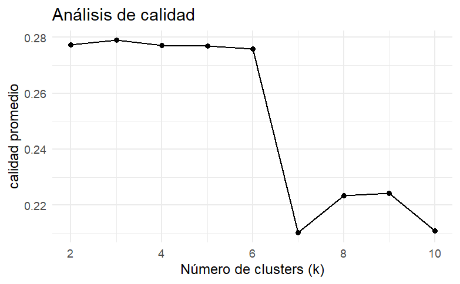

```r
#

calidad_prom <- map_dbl(
  2:10,
  function(k) {
    km <- kmeans(matriz_clustering_scaled, centers = k, nstart = 25)
    sil <- silhouette(km$cluster, dist(matriz_clustering_scaled))
    mean(sil[, 3])
  }
)

sil_df <- tibble(
  k = 2:10,
  calidad = calidad_prom
)

ggplot(sil_df, aes(k, calidad)) +
  geom_line() +
  geom_point() +
  labs(
    title = "Análisis de calidad",
    x = "Número de clusters (k)",
    y = "calidad promedio"
  ) +
  theme_minimal()
```

## 4.2 Aplicación del algoritmo K-means

Definido el número de clusters, se aplicó el algoritmo de **K-means** sobre la matriz de datos construida a partir de los scores del Análisis de Componentes Principales (PCA). El uso de estos scores permite trabajar con variables sintéticas, no correlacionadas entre sí, que resumen las principales dimensiones de desempeño municipal, evitando problemas de multicolinealidad y escalas heterogéneas.

El resultado del procedimiento es una tipología de municipios agrupados en conjuntos relativamente homogéneos en términos de sus características estructurales. La asignación a clusters se incorporó como una nueva variable en la base de datos, la cual es utilizada posteriormente para la interpretación de perfiles y el análisis territorial.

```r
#
set.seed(123)

k_optimo <- 6

kmeans_final <- kmeans(
  matriz_clustering_scaled,
  centers = k_optimo,
  nstart = 50
)

base_perfiles <- base_perfiles %>%
  mutate(cluster_kmeans = factor(kmeans_final$cluster))
```

```r
perfiles_clusters <- base_perfiles %>%
  group_by(cluster_kmeans) %>%
  summarise(
    across(
      c(
        educacion_nivel,
        laboral_desempeno,
        laboral_participacion,
        laboral_empleo_publico,
        servicios_acceso_general,
        servicios_composicion,
        tics_acceso_general,
        tics_tipo_acceso,
        etnia_presencia,
        etnia_composicion
      ),
      mean,
      na.rm = TRUE
    ),
    n_municipios = n(),
    .groups = "drop"
  )
```

```r
perfiles_clusters <- perfiles_clusters %>%
  left_join(
    base_perfiles %>%
      group_by(cluster_kmeans) %>%
      summarise(
        poblacion_promedio = mean(poblacion, na.rm = TRUE),
        proporcion_urbano = mean(urbano, na.rm = TRUE),
        .groups = "drop"
      ),
    by = "cluster_kmeans"
  )
#muestro que el 6 tiene muy pocas unidades territoriales
base_perfiles %>%
  count(cluster_kmeans) %>%
  mutate(porcentaje = n / sum(n))
```

| cluster_kmeans | n | porcentaje |
| --- | --- | --- |
| 1 | 302 | 0.137899543 |
| 2 | 191 | 0.087214612 |
| 3 | 105 | 0.047945205 |
| 4 | 502 | 0.229223744 |
| 5 | 1069 | 0.488127854 |
| 6 | 21 | 0.009589041 |

```r
#veo si alguno esta muy dominado por grandes ciudades
base_perfiles %>%
  group_by(cluster_kmeans) %>%
  summarise(
    poblacion_mediana = median(poblacion, na.rm = TRUE),
    poblacion_max = max(poblacion, na.rm = TRUE)
  )
```

| cluster_kmeans | poblacion_mediana | poblacion_max |
| --- | --- | --- |
| 1 | 415.0 | 326527 |
| 2 | 1644.0 | 79130 |
| 3 | 597.0 | 18239 |
| 4 | 2397.5 | 101086 |
| 5 | 5961.0 | 1837168 |
| 6 | 534.0 | 20470 |

```r
#veo proporcion urbana vs rural
base_perfiles %>%
  group_by(cluster_kmeans) %>%
  summarise(
    prop_urbano = mean(urbano, na.rm = TRUE)
  )
```

| cluster_kmeans | prop_urbano |
| --- | --- |
| 1 | 0.01524529 |
| 2 | 0.13009708 |
| 3 | 0.00000000 |
| 4 | 0.02319770 |
| 5 | 0.18878574 |
| 6 | 0.00000000 |

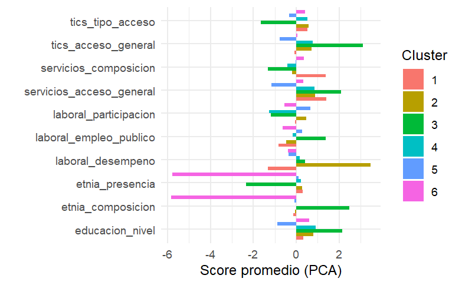

```r
# ======================================================
# TABLA 5 – TAMAÑO DE CLUSTERS
# ======================================================

tamano_clusters <- base_perfiles %>%
  count(cluster_kmeans) %>%
  mutate(
    porcentaje = n / sum(n)
  )

write_xlsx(
  tamano_clusters,
  "outputs/tablas/05_tamano_clusters.xlsx"
)
##########################


#grafico
perfiles_clusters %>%
  select(-n_municipios, -poblacion_promedio, -proporcion_urbano) %>%
  pivot_longer(
    cols = -cluster_kmeans,
    names_to = "dimension",
    values_to = "score"
  ) %>%
  ggplot(aes(dimension, score, fill = factor(cluster_kmeans))) +
  geom_col(position = "dodge") +
  coord_flip() +
  labs(
    fill = "Cluster",
    x = "",
    y = "Score promedio (PCA)"
  ) +
  theme_minimal()
```

```r
# ======================================================
# TABLA 2 – PERFILES PROMEDIO KMEANS
# ======================================================

write_xlsx(
  perfiles_clusters,
  "outputs/tablas/02_perfiles_clusters_kmeans.xlsx"
)
```

## 4.3 Comparación de la varianza intra-cluster entre métodos de agrupamiento

El análisis de varianza intra-cluster permite evaluar el grado de **homogeneidad interna** de los grupos obtenidos mediante distintas técnicas de clustering. Este indicador mide cuán similares son entre sí los municipios que integran un mismo cluster respecto de las variables analizadas. Valores más bajos indican grupos más compactos, es decir, con menor dispersión interna y mayor coherencia en términos socioeconómicos.

Los resultados obtenidos muestran que el método jerárquico de Ward presenta sistemáticamente menores niveles de varianza intra-cluster que el algoritmo K-means en todas las dimensiones consideradas: Educación, Etnia, Laboral, Servicios y TICs. Esto implica que los clusters jerárquicos tienden a reunir municipios con características más homogéneas dentro de cada grupo, lo cual es consistente con la lógica del método Ward, cuyo criterio de fusión minimiza la varianza interna en cada etapa del proceso de agrupamiento.

Desde el punto de vista sustantivo, una mayor homogeneidad interna sugiere que los territorios agrupados comparten perfiles socioeconómicos más cercanos, lo que facilita la interpretación de patrones estructurales. Por ejemplo, en Educación y Etnia —donde las diferencias entre métodos son más pronunciadas— el clustering jerárquico logra distinguir con mayor precisión territorios con rezagos estructurales frente a aquellos con mejores indicadores sociales.

En dimensiones como TICs y Servicios, las diferencias entre métodos son menores, lo que sugiere que estas variables presentan patrones territoriales relativamente claros y consistentes independientemente del algoritmo utilizado. Por su parte, la dimensión laboral muestra resultados estables entre métodos, indicando que los perfiles ocupacionales constituyen una base robusta de diferenciación territorial.

Implicancias analíticas:

La compacidad de los clusters tiene implicancias metodológicas y sustantivas relevantes. Grupos más homogéneos permiten caracterizar perfiles territoriales más definidos y facilitan la interpretación comparativa entre clusters. Sin embargo, una excesiva homogeneidad también puede implicar una fragmentación excesiva del espacio territorial, generando clusters muy específicos pero menos generalizables.

En contexto de construcción de tipologías territoriales —como el presente trabajo— no sólo interesa la homogeneidad interna, sino también la **capacidad del método para producir grupos estables, interpretables y replicables**. Por ello, la evaluación de la varianza intra-cluster debe complementarse con criterios de estabilidad, asignación directa y claridad interpretativa.

Si bien el método jerárquico de Ward produce clusters más compactos en términos de varianza interna, el algoritmo K-means resulta más adecuado para la construcción de la tipología final de municipios. En primer lugar, K-means permite una asignación directa y reproducible de cada unidad a un cluster específico, facilitando la actualización futura del análisis ante nuevos datos. En segundo lugar, los resultados obtenidos mediante ambos métodos muestran patrones de diferenciación territorial similares, lo que indica que la estructura general de los grupos es robusta y no depende exclusivamente del algoritmo utilizado.

Asimismo, K-means ofrece centroides claramente definidos que representan perfiles promedio de cada cluster, lo que favorece la caracterización sustantiva de los grupos y su interpretación en términos de políticas públicas. En este sentido, la elección de K-means no implica descartar el método jerárquico, sino utilizarlo como estrategia complementaria de validación y contraste metodológico.

```r
scores_educacion <- c("educacion_nivel")

scores_laboral <- c(
  "laboral_desempeno",
  "laboral_participacion",
  "laboral_empleo_publico"
)

scores_servicios <- c(
  "servicios_acceso_general",
  "servicios_composicion"
)

scores_tics <- c(
  "tics_acceso_general",
  "tics_tipo_acceso"
)

scores_etnia <- c(
  "etnia_presencia",
  "etnia_composicion"
)


# Distancia euclídea
distancias <- dist(matriz_clustering_scaled, method = "euclidean")

# Clustering jerárquico (Ward)
hclust_ward <- hclust(distancias, method = "ward.D2")

# Cortamos en k = 6 (mismo k que k-means)
base_perfiles <- base_perfiles %>%
  mutate(cluster_hclust = factor(cutree(hclust_ward, k = 6)))

var_intra <- function(data, cluster_var, vars_dimension) {
  data %>%
    group_by(.data[[cluster_var]]) %>%
    summarise(
      across(
        all_of(vars_dimension),
        ~ var(.x, na.rm = TRUE)
      ),
      .groups = "drop"
    ) %>%
    mutate(
      var_intra_media = rowMeans(
        select(., all_of(vars_dimension)),
        na.rm = TRUE
      )
    )
}

################ K-means

var_educ_kmeans <- var_intra(base_perfiles, "cluster_kmeans", scores_educacion)
var_laboral_kmeans <- var_intra(base_perfiles, "cluster_kmeans", scores_laboral)
var_servicios_kmeans <- var_intra(base_perfiles, "cluster_kmeans", scores_servicios)
var_tics_kmeans <- var_intra(base_perfiles, "cluster_kmeans", scores_tics)
var_etnia_kmeans <- var_intra(base_perfiles, "cluster_kmeans", scores_etnia)


###################### Jerarquico

var_educ_hclust <- var_intra(base_perfiles, "cluster_hclust", scores_educacion)
var_laboral_hclust <- var_intra(base_perfiles, "cluster_hclust", scores_laboral)
var_servicios_hclust <- var_intra(base_perfiles, "cluster_hclust", scores_servicios)
var_tics_hclust <- var_intra(base_perfiles, "cluster_hclust", scores_tics)
var_etnia_hclust <- var_intra(base_perfiles, "cluster_hclust", scores_etnia)

#################### Tabla comparativa

tabla_varianza <- bind_rows(
  var_educ_kmeans %>% mutate(dimension = "Educación", metodo = "K-means"),
  var_laboral_kmeans %>% mutate(dimension = "Laboral", metodo = "K-means"),
  var_servicios_kmeans %>% mutate(dimension = "Servicios", metodo = "K-means"),
  var_tics_kmeans %>% mutate(dimension = "TICs", metodo = "K-means"),
  var_etnia_kmeans %>% mutate(dimension = "Etnia", metodo = "K-means"),

  var_educ_hclust %>% mutate(dimension = "Educación", metodo = "Jerárquico (Ward)"),
  var_laboral_hclust %>% mutate(dimension = "Laboral", metodo = "Jerárquico (Ward)"),
  var_servicios_hclust %>% mutate(dimension = "Servicios", metodo = "Jerárquico (Ward)"),
  var_tics_hclust %>% mutate(dimension = "TICs", metodo = "Jerárquico (Ward)"),
  var_etnia_hclust %>% mutate(dimension = "Etnia", metodo = "Jerárquico (Ward)")
) %>%
  group_by(dimension, metodo) %>%
  summarise(
    var_intra_media = mean(var_intra_media, na.rm = TRUE),
    .groups = "drop"
  )
# ======================================================
# TABLA 3 – VARIANZA INTRA CLUSTER
# ======================================================

write_xlsx(
  tabla_varianza,
  "outputs/tablas/03_varianza_intra_cluster.xlsx"
)
########################


DT::datatable(
  tabla_varianza,
  rownames = FALSE,
  options = list(
    dom = "t",
    pageLength = 10
  ),
  caption = "Varianza intra-cluster media por dimensión y método de clustering"
)
```

| dimension | metodo | var_intra_media |
| --- | --- | --- |
| Educación | Jerárquico (Ward) | 0.770731180204454 |
| Educación | K-means | 0.9834426586661191 |
| Etnia | Jerárquico (Ward) | 1.574547883618177 |
| Etnia | K-means | 2.156595323941537 |
| Laboral | Jerárquico (Ward) | 1.319167571537848 |
| Laboral | K-means | 1.489167260806284 |
| Servicios | Jerárquico (Ward) | 1.170838554340414 |
| Servicios | K-means | 1.263444640739088 |
| TICs | Jerárquico (Ward) | 0.5254137760625728 |
| TICs | K-means | 0.5750933180002388 |

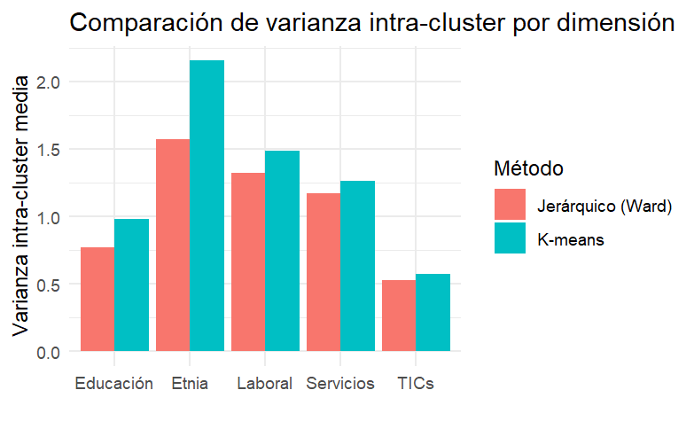

```r
ggplot(tabla_varianza,
       aes(x = dimension, y = var_intra_media, fill = metodo)) +
  geom_col(position = "dodge") +
  labs(
    title = "Comparación de varianza intra-cluster por dimensión",
    x = "",
    y = "Varianza intra-cluster media",
    fill = "Método"
  ) +
  theme_minimal()
```

## 4.5 Caracterización de los Clusters Municipales

### Comparación de centroides entre K-means y Jerárquico

La comparación de centroides consiste en analizar los valores promedio de las variables o componentes principales dentro de cada cluster. Cada centroide representa el perfil socioeconómico típico de los municipios que integran el grupo. Al comparar los centroides obtenidos mediante K-means y clustering jerárquico, es posible evaluar si ambos métodos generan tipologías territoriales similares o si producen perfiles sustancialmente distintos.

Este análisis permite validar la estabilidad sustantiva de los clusters: si los perfiles promedio son comparables entre métodos, se refuerza la robustez de la clasificación territorial. Asimismo, la comparación de centroides facilita la interpretación sustantiva de los grupos, ya que permite identificar qué dimensiones presentan valores altos o bajos en cada cluster y construir perfiles tipo de municipios.

Esto refuerza la validez de la tipología construida mediante K-means, al tiempo que justifica su uso como clasificación final por su mayor flexibilidad operativa.

```r
# ------------------------------------------------------
# 1. VARIABLES DE SCORES PCA UTILIZADAS EN CLUSTERING
# ------------------------------------------------------

vars_scores <- c(
  "educacion_nivel",
  "laboral_desempeno",
  "laboral_participacion",
  "laboral_empleo_publico",
  "servicios_acceso_general",
  "servicios_composicion",
  "tics_acceso_general",
  "tics_tipo_acceso",
  "etnia_presencia",
  "etnia_composicion"
)

# ------------------------------------------------------
# 2. CENTROIDES KMEANS
# ------------------------------------------------------

centroides_kmeans <- base_perfiles %>%
  group_by(cluster_kmeans) %>%
  summarise(
    across(all_of(vars_scores), mean, na.rm = TRUE),
    .groups = "drop"
  ) %>%
  mutate(metodo = "K-means") %>%
  rename(cluster = cluster_kmeans)

# ------------------------------------------------------
# 3. CENTROIDES JERARQUICOS
# ------------------------------------------------------

centroides_jerarq <- base_perfiles %>%
  group_by(cluster_hclust) %>%
  summarise(
    across(all_of(vars_scores), mean, na.rm = TRUE),
    .groups = "drop"
  ) %>%
  mutate(metodo = "Jerárquico") %>%
  rename(cluster = cluster_hclust)

# ------------------------------------------------------
# 4. TABLA COMPARATIVA FINAL
# ------------------------------------------------------

tabla_centroides <- bind_rows(
  centroides_kmeans,
  centroides_jerarq
)

print(tabla_centroides)
```

| cluster | educacion_nivel | laboral_desempeno | laboral_participacion | laboral_empleo_publico | servicios_acceso_general | servicios_composicion | tics_acceso_general | tics_tipo_acceso | etnia_presencia | etnia_composicion | metodo |
| --- | --- | --- | --- | --- | --- | --- | --- | --- | --- | --- | --- |
| 1 | 0.3253376 | -1.3207613 | -0.04701606 | -0.8141699 | 1.3946073 | 1.35871894 | -0.08844992 | 0.52956994 | 0.3032281 | -0.132891065 | K-means |
| 2 | 0.8050965 | 3.4749760 | 0.46937110 | -0.4633478 | 0.8658829 | -0.18939155 | 0.72491112 | 0.56244101 | 0.2681896 | -0.051667965 | K-means |
| 3 | 2.1540515 | 0.4212071 | -1.17862577 | 1.3829369 | 2.0807086 | -1.31494732 | 3.09204969 | -1.64676330 | -2.3487018 | 2.461864774 | K-means |
| 4 | 0.8975186 | 0.1759086 | -1.26382958 | -0.1726327 | 0.8560838 | -0.42295221 | 0.76823730 | 0.51802468 | 0.2067778 | -0.005103843 | K-means |
| 5 | -0.8806758 | -0.3641597 | 0.64953395 | 0.2703726 | -1.1614417 | -0.02901935 | -0.77015295 | -0.33981623 | 0.1136012 | -0.078215114 | K-means |
| 6 | 0.6041577 | -0.3855550 | -0.55260298 | -0.6283970 | 0.3236963 | 0.34542034 | 0.05842941 | 0.41756893 | -5.7822643 | -5.824763442 | K-means |
| 1 | -0.8171114 | -0.2683111 | 0.62966567 | 0.2300549 | -1.1060815 | -0.04153108 | -0.71677072 | -0.29831392 | 0.1170140 | -0.077219079 | Jerárquico |
| 2 | 0.7453029 | -0.2090174 | -0.95403362 | -0.5039075 | 0.9250711 | 0.07482920 | 0.50098750 | 0.62705249 | 0.1469215 | -0.166372669 | Jerárquico |
| 3 | 1.8994061 | 0.6986096 | -1.40657800 | 1.0696183 | 2.0788560 | -1.10342404 | 2.41520253 | -0.88687150 | -1.3187905 | 1.465016652 | Jerárquico |
| 4 | 1.0153543 | 3.9662427 | 0.65864231 | -0.6765038 | 1.3276425 | -0.09349025 | 0.79265383 | 0.72529400 | 0.3747315 | -0.069496410 | Jerárquico |

[output cut: 2 more lines]

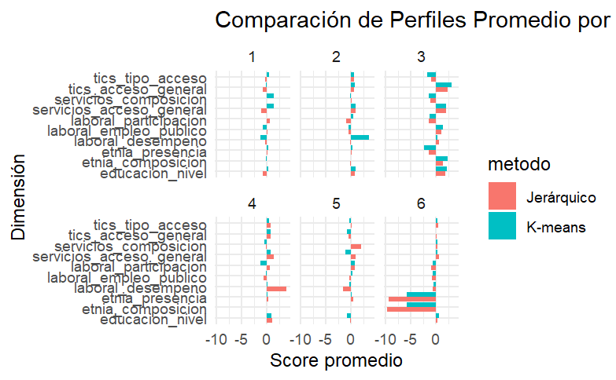

```r
# ======================================================
# TABLA 4 – CENTROIDES COMPARADOS
# ======================================================

write_xlsx(
  tabla_centroides,
  "outputs/tablas/04_centroides_comparados.xlsx"
)



# ------------------------------------------------------
# 5. FORMATO LARGO PARA GRAFICO
# ------------------------------------------------------

tabla_long <- tabla_centroides %>%
  pivot_longer(
    cols = all_of(vars_scores),
    names_to = "dimension",
    values_to = "valor"
  )

# ------------------------------------------------------
# 6. GRAFICO COMPARATIVO DE PERFILES PROMEDIO
# ------------------------------------------------------

ggplot(tabla_long,
       aes(x = dimension,
           y = valor,
           fill = metodo)) +
  geom_col(position = "dodge") +
  facet_wrap(~cluster) +
  coord_flip() +
  labs(
    title = "Comparación de Perfiles Promedio por Cluster",
    x = "Dimensión",
    y = "Score promedio"
  ) +
  theme_minimal()
```

### Cluster 1 – Municipios con fuerte acceso a servicios, pero debilidad laboral

En términos educativos, el nivel es levemente superior al promedio, aunque no constituye una fortaleza central. La dimensión TIC muestra un acceso cercano a la media, con cierta ventaja en el tipo de acceso más que en la cobertura general.

Estos municipios pueden interpretarse como territorios con **infraestructura consolidada**, pero con **problemas estructurales de inserción laboral**, lo que sugiere una desconexión entre el acceso a servicios y las oportunidades económicas locales.

### Cluster 2 – Municipios con buen desempeño laboral y educativo, pero heterogeneidad participativa

Sin embargo, se observa cierta **heterogeneidad en la participación laboral**, lo que sugiere que los buenos indicadores de empleo no se distribuyen de manera homogénea entre la población activa.

Este perfil corresponde a municipios con **estructuras socioeconómicas relativamente dinámicas**, que combinan capital humano elevado con mercados de trabajo funcionales, aunque con desigualdades internas que matizan ese buen desempeño general.

### Cluster 3 – Municipios de alto desarrollo estructural y fuerte diferenciación socioterritorial

No obstante, este alto desarrollo convive con una **baja participación laboral** y una fuerte diferenciación en la dimensión étnica, tanto en presencia como en composición. Esto indica territorios con **estructuras complejas**, donde el desarrollo material no necesariamente se traduce en inclusión laboral plena.

Se trata de municipios con **altas capacidades institucionales y de infraestructura**, pero con tensiones internas asociadas a desigualdades sociales persistentes.

### Cluster 4 – Municipios de desempeño intermedio con buen acceso a TICs y servicios

Este perfil refleja municipios con **condiciones estructurales razonables**, pero sin un mercado de trabajo dinámico que aproveche plenamente ese capital social y tecnológico. La presencia étnica es moderada y no constituye un rasgo distintivo central.

Son territorios que podrían beneficiarse de políticas orientadas a **articular infraestructura y capital humano con estrategias de desarrollo productivo local**.

### Cluster 5 – Municipios con rezagos estructurales múltiples

Con 1.069 municipios (casi la mitad del total) y una población promedio de 37.832 habitantes, este cluster concentra los municipios de mayor tamaño relativo y mayor proporción urbana (18,9%).

La composición étnica no presenta extremos, pero se inserta en un contexto general de rezago estructural. Este perfil refleja territorios con **carencias múltiples**, donde las limitaciones educativas, infraestructurales y tecnológicas se refuerzan mutuamente.

Desde una perspectiva de política pública, estos municipios requieren **intervenciones integrales**, priorizando el acceso a servicios, educación y conectividad como condiciones básicas para el desarrollo.

### Cluster 6 – Municipios con fuerte especificidad étnica y aislamiento estructural

El sexto cluster (21 municipios) es muy minoritario. Presenta un perfil claramente diferenciado, con **valores extremadamente bajos en las dimensiones étnicas**, lo que indica una fuerte concentración o particularidad en la composición poblacional. A su vez, muestra **desempeños bajos en participación y empleo**, junto con niveles moderados de acceso a servicios y TICs.

Este patrón sugiere municipios con **alta especificidad sociocultural**, probablemente pequeños o rurales, donde las dinámicas económicas y laborales están fuertemente condicionadas por factores estructurales y territoriales.

Se trata de territorios que requieren **políticas focalizadas y culturalmente pertinentes**, ya que los instrumentos estándar de desarrollo pueden resultar insuficientes o inadecuados.

# 5. Validación e interpretación con Random Forest

Con el objetivo de validar la consistencia interna y la interpretabilidad de la tipología territorial obtenida mediante el algoritmo K-means, se implementó un modelo de clasificación supervisada utilizando el algoritmo Random Forest. Este enfoque permite evaluar en qué medida las dimensiones utilizadas en el clustering contribuyen efectivamente a diferenciar los grupos identificados.

A diferencia de los métodos no supervisados, como K-means o el clustering jerárquico, que identifican agrupamientos sin una variable objetivo explícita, el Random Forest es un método supervisado que construye múltiples árboles de decisión para predecir la pertenencia a cada cluster a partir de las variables explicativas. En este caso, la variable dependiente fue la asignación a cluster obtenida mediante K-means, mientras que las variables independientes fueron los scores de los componentes principales correspondientes a las dimensiones de educación, mercado laboral, acceso a servicios, acceso a tecnologías de la información y comunicación, y composición étnica.

Este procedimiento permite evaluar si los clusters identificados constituyen grupos estructuralmente diferenciados y, adicionalmente, identificar cuáles dimensiones son más relevantes para explicar dicha diferenciación.

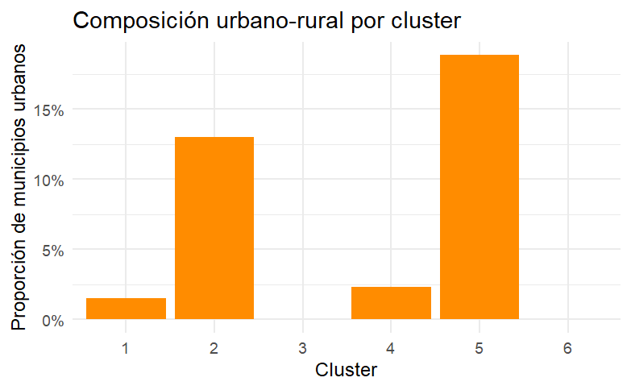

```r
# ------------------------------------------------------
# 6. Visualización urbano / rural
# ------------------------------------------------------

ggplot(urbano_cluster,
       aes(x = cluster_kmeans, y = proporcion_urbano)) +
  geom_col(fill = "darkorange") +
  scale_y_continuous(labels = scales::percent_format()) +
  labs(
    title = "Composición urbano-rural por cluster",
    x = "Cluster",
    y = "Proporción de municipios urbanos"
  ) +
  theme_minimal()

# Accuracy del modelo

pred <- predict(rf_model, rf_data)

accuracy <- mean(pred == rf_data$cluster_kmeans)

accuracy
```

```
[1] 1
```

```r
#matriz de confusion
table(
  Real = rf_data$cluster_kmeans,
  Predicho = predict(rf_model, rf_data)
)
```

```
    Predicho
Real    1    2    3    4    5    6
   1  302    0    0    0    0    0
   2    0  191    0    0    0    0
   3    0    0  105    0    0    0
   4    0    0    0  502    0    0
   5    0    0    0    0 1069    0
   6    0    0    0    0    0   21
```

```r
# ======================================================
# TABLA 8 – CORRELACIÓN ENTRE DIMENSIONES PCA
# ======================================================

correlacion_dimensiones <- base_perfiles %>%
  select(all_of(vars_scores)) %>%
  cor()

write_xlsx(
  as.data.frame(correlacion_dimensiones),
  "outputs/tablas/08_correlacion_dimensiones_pca.xlsx"
)
```

### 5.1 Importancia de variables y capacidad discriminante

Adicionalmente, el modelo alcanza una precisión del 100% en la clasificación de los municipios en sus respectivos clusters. Este resultado indica que los perfiles territoriales presentan una clara separación en el espacio multidimensional definido por las dimensiones estructurales analizadas. Desde una perspectiva metodológica, esto confirma la alta consistencia interna de la tipología y demuestra que los clusters obtenidos mediante K-means no constituyen una partición arbitraria, sino configuraciones coherentes y bien delimitadas.

### 5.2 Interpretación territorial y pertinencia para políticas públicas

Desde la perspectiva de la formulación de políticas públicas, esta diferenciación resulta especialmente relevante. La identificación de grupos de municipios con características estructurales similares permite diseñar intervenciones más focalizadas y ajustadas a las necesidades específicas de cada perfil territorial. En lugar de aplicar estrategias homogéneas para territorios heterogéneos, la tipología construida facilita la planificación de políticas diferenciadas en materia de desarrollo productivo, infraestructura, inclusión digital, educación y fortalecimiento institucional.

En este sentido, la robustez estadística de la clasificación —validada mediante Random Forest— refuerza su utilidad como herramienta para la planificación territorial y la asignación estratégica de recursos públicos, contribuyendo a una implementación más eficiente y equitativa de políticas orientadas a reducir desigualdades territoriales.

# 6. Conclusión general

El presente trabajo tuvo como objetivo construir una tipología territorial de municipios a partir de información multidimensional estandarizada, con el fin de identificar patrones estructurales de desigualdad territorial y generar una herramienta analítica útil para el diseño de políticas públicas diferenciadas.

Para ello, en una primera etapa se aplicó Análisis de Componentes Principales (PCA) sobre las distintas dimensiones relevantes del desarrollo territorial —educación, mercado laboral, acceso a servicios, tecnologías de la información y composición étnica—. Esta técnica permitió reducir la dimensionalidad del conjunto de indicadores originales, sintetizando la información en un número reducido de componentes que capturan las principales fuentes de variación estructural entre municipios. La construcción de scores por dimensión permitió obtener variables comparables, independientes entre sí y libres de redundancias estadísticas, facilitando su utilización en técnicas de aprendizaje no supervisado.

Desde la perspectiva de política pública, esta tipología constituye una herramienta particularmente valiosa para el diseño e implementación de estrategias territorialmente diferenciadas. La evidencia muestra que los municipios no forman un conjunto homogéneo, sino que presentan perfiles estructurales claramente diferenciados en términos de capacidades, oportunidades y condiciones socioeconómicas. En este sentido, la tipología permite identificar territorios prioritarios para la expansión de infraestructura básica, fortalecer políticas de inclusión laboral en municipios con debilidad estructural, y diseñar estrategias específicas de desarrollo territorial adaptadas a las características particulares de cada grupo de municipios.

En conjunto, los resultados demuestran la utilidad de los métodos de reducción dimensional y aprendizaje no supervisado como herramientas para el análisis territorial, permitiendo transformar grandes volúmenes de información multidimensional en tipologías interpretables, empíricamente robustas y directamente aplicables al diseño de políticas públicas basadas en evidencia.